# hotHandAnalysis

Ben Peloquin

May 6, 2016

Prelims

# Section I - General data orientation

Read in data. First check for consolidated `full_season_data_payer_info.csv`, otherwise create. (See `get_data.py` for data collection code)

```r
## Note this takes appr 2min to run
d.raw <- read.csv(paste0(data_path, "full_season_data_player_info.csv"))

if (!inGlobalEnv("d.raw")) {
  files <- list.files(path)
  d.raw <- data.frame()
  for (f in files) {
    d <- read.csv(paste0(path, f))
    d.raw <- rbind(d.raw, d)
  }

  d.player_info <- read.csv("player_info/players_info.csv") %>%
    select(player_number, age, weight, height, years_in_league, player_id, position)
  names(d.player_info) <- c("PLAYER_NUMBER", "AGE", "WEIGHT", "HEIGHT", "YEARS_IN_LEAGUE", "PLAYER_ID", "POSITION")

  d.raw <- full_join(d.raw, d.player_info, by = 'PLAYER_ID')
  write.csv(d.raw, "full_season_data_player_info.csv")
}
```

## Pre-processing

We have 197206 observations with 29 predictor variables.

There are a number of predictors we might want to recode. Looks like `GAME_ID`, `GAME_EVENT_ID`, `PLAYER_ID`, `TEAM_ID`, `PERIOD`, `SHOT_ATTEMPTED_FLAG`, and `SHOT_MADE_FLAG` should all be coded as factors (currently coded as ints). Let’s also convert `SHOT_TYPE` to an integer value…

```r
d <- d.raw %>%
  mutate(GAME_ID = as.factor(GAME_ID),
         GAME_EVENT_ID = as.factor(GAME_EVENT_ID),
         PLAYER_ID = as.factor(PLAYER_ID),
         TEAM_ID = as.factor(TEAM_ID),
         PERIOD = as.factor(PERIOD),
         SHOT_VALUE = ifelse(SHOT_TYPE == "2PT Field Goal", 2, 3),
         TOTAL_TIME_REMAINING = SECONDS_REMAINING + 60 * MINUTES_REMAINING)
```

Let’s do some preliminary exploring just to make sure this data makes sense…

## Basic data orientation / summary

### Number of shots by player

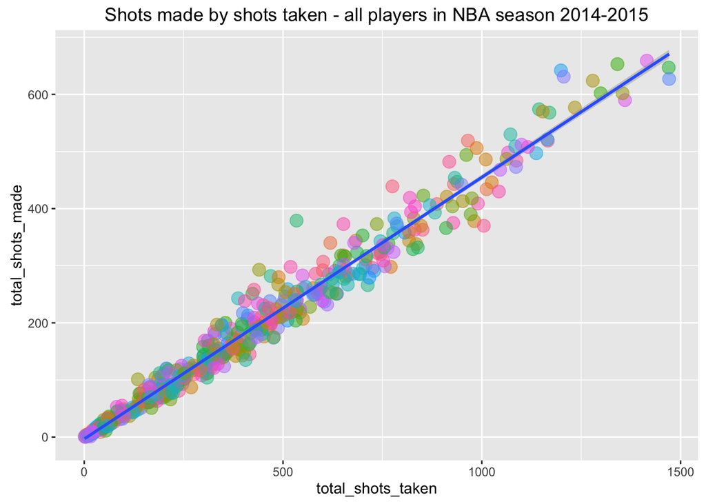

```r
player_shots_summary <- d %>%
  group_by(PLAYER_NAME, TEAM_NAME) %>%
  summarize(total_shots_taken = n(),
            total_shots_made = sum(SHOT_MADE_FLAG),
            shooting_percentage = total_shots_made / total_shots_taken)

ggplot(player_shots_summary, aes(x = total_shots_taken, y = total_shots_made, col = TEAM_NAME)) +
  geom_point(alpha = 0.5, size = 4) +
  geom_smooth(method = "lm", aes(group=1)) +
  guides(col = FALSE) +
  ggtitle("Shots made by shots taken - all players in NBA season 2014-2015")
```

### Total number of shots taken

```r
sum(player_shots_summary$total_shots_taken)
```

```
## [1] 197206
```

### Total number of shots made

```r
sum(player_shots_summary$total_shots_made)
```

```
## [1] 88815
```

### Number of players

```r
length(unique(d$PLAYER_ID)) == length(unique(d$PLAYER_NAME))
```

```
## [1] TRUE
```

```r
length(unique(d$PLAYER_ID))
```

```
## [1] 400
```

### Number of teams

```r
length(unique(d$TEAM_ID))
```

```
## [1] 30
```

Looks good, there are 30 teams

# Section II - Populating streak info

Check for pre-consolidated streak info in `d_prev_shots.csv`. If not write to new .csv. See (https://github.com/benpeloquin7/hot_hand/blob/master/analysis/analysis_helpers.R) for `populate_prev_shot()` helper functionality.

```r
d_prev <- read.csv(paste0(data_path, "d_prev_shots.csv"))

if (!inGlobalEnv("d_prev")) {
  print("Writing d_prev_shots.csv... takes ~20min")
  ptm <- proc.time()
  ## Caution this takes ~5min to run
  d_prev <- populate_prev_shots(d)
  proc.time() - ptm
  write.csv(d_prev, "d_prev_shots.csv")
}
```

# Section III - Analysis

## Question 1: Global conditional probabilities

### Data prep

This makes a test of the GVT’s finding that an arbitrary players’ shooting percentage should increase conditioned on a previously made shot.

```r
## Conditional probs
overall_cond_df <- d_prev %>%
  mutate(cond_probs_hit = ifelse(curr_hit_streak == 1, "1",
                                 ifelse(curr_hit_streak == 2, "2",
                                        ifelse(curr_hit_streak == 3, "3", "4+"))),
         cond_probs_miss = ifelse(curr_miss_streak == 1, "1",
                                 ifelse(curr_miss_streak == 2, "2",
                                        ifelse(curr_miss_streak == 3, "3", "4+")))) %>%
  gather(cond_probs_type, cond_probs_value, c(cond_probs_hit, cond_probs_miss)) %>%
  group_by(cond_probs_type, cond_probs_value) %>%
  summarize(shots_taken = n(),
            avg_shot_distance = mean(SHOT_DISTANCE),
            sd_shot_distance = sd(SHOT_DISTANCE),
            shots_made = sum(SHOT_MADE_FLAG),
            shooting_percentage = shots_made / shots_taken,
            ci_lower = binom.test(shots_made, shots_taken)$conf.int[1],
            ci_upper = binom.test(shots_made, shots_taken)$conf.int[2])

## Overall probs
overall_row <- d_prev %>%
  mutate(cond_probs_type = "overall",
         cond_probs_value = 0) %>%
  group_by(cond_probs_type, cond_probs_value) %>%
  summarise(shots_taken=n(),
            avg_shot_distance = mean(SHOT_DISTANCE),
            sd_shot_distance = sd(SHOT_DISTANCE),
            shots_made = sum(SHOT_MADE_FLAG),
            shooting_percentage = shots_made / shots_taken,
            ci_lower = binom.test(shots_made, shots_taken)$conf.int[1],
            ci_upper = binom.test(shots_made, shots_taken)$conf.int[2])

## Combine data
overall_cond_df <- rbind(overall_cond_df, overall_row)
overall_cond_df$context <- c("made_1", "made_2", "made_3", "made_4+",
                             "missed_1", "missed_2", "missed_3", "missed_4+",
                             "overall")
row_order <- c("missed_4+", "missed_3", "missed_2", "missed_1", "overall", "made_1", "made_2", "made_3", "made_4+")

## Format for plotting
overall_cond_df <- overall_cond_df[match(row_order, overall_cond_df$context), ]
overall_cond_df$context <- factor(overall_cond_df$context, levels = c('made_4+',
                                                                      'made_3',
                                                                      'made_2',
                                                                      'made_1',
                                                                      'overall',
                                                                      'missed_1',
                                                                      'missed_2',
                                                                      'missed_3',
                                                                      'missed_4+'))
## Populate standard errors
overall_cond_df <- overall_cond_df %>%
  mutate(se = ci_upper - ci_lower / 3.92)
```

### t-test

Crude, but makes a test of the hypothesis

```r
## t-test for made prev shot
## ------------------------
n1 <- overall_cond_df[4, ]$shots_taken       ## missed previous
n2 <- overall_cond_df[6, ]$shots_taken       ## made previous
sd1 <- overall_cond_df[4, ]$se / sqrt(n1)
sd2 <- overall_cond_df[6, ]$se / sqrt(n2)
shooting_per1 <- overall_cond_df[4, ]$shooting_percentage
shooting_per2 <- overall_cond_df[6, ]$shooting_percentage
se <- sqrt(sd1^2/n1 + sd2^2/n2)
t <- (shooting_per2 - shooting_per1) / se
p <- pt(t, n1 + n2 - 2)
cat(paste0("t = ", t), "\n", paste0("p < 0.001"))
```

```
## t = -1260.0465296324
##  p < 0.001
```

### Plot

```r
overall_cond_df %>%
  select(shooting_percentage, ci_lower, ci_upper)
```

```
## Source: local data frame [9 x 4]
## Groups: cond_probs_type [3]
##
##   cond_probs_type shooting_percentage  ci_lower  ci_upper
##             (chr)               (dbl)     (dbl)     (dbl)
## 1 cond_probs_miss           0.4455595 0.4426392 0.4484826
## 2 cond_probs_miss           0.4592673 0.4499670 0.4685888
## 3 cond_probs_miss           0.4532034 0.4468789 0.4595393
## 4 cond_probs_miss           0.4576542 0.4533093 0.4620040
## 5         overall           0.4503666 0.4481690 0.4525657
## 6  cond_probs_hit           0.4452970 0.4408420 0.4497587
## 7  cond_probs_hit           0.4524479 0.4453892 0.4595211
## 8  cond_probs_hit           0.4464633 0.4353203 0.4576469
## 9  cond_probs_hit           0.4522731 0.4494812 0.4550673
```

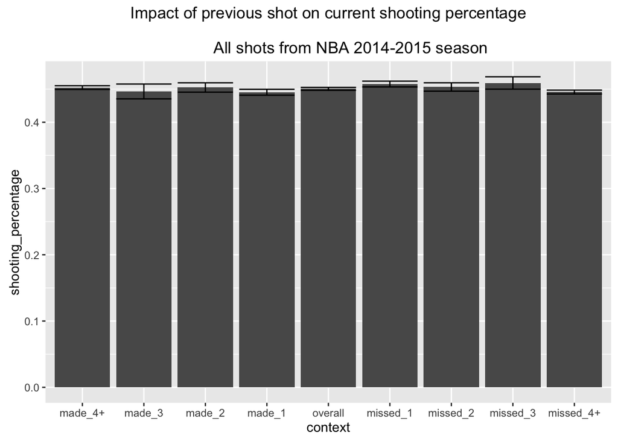

```r
ggplot(overall_cond_df, aes(x = context, y = shooting_percentage)) +
  geom_bar(stat = "identity") +
  geom_errorbar(aes(ymin = ci_lower, ymax = ci_upper)) +
  ggtitle("Impact of previous shot on current shooting percentage\n
          All shots from NBA 2014-2015 season")
```

## Question 2: Wald-Wolfowitz run test

Tests whether the observed number of runs differs from what would be expected by chance alone. Calculates (observed - expected) number of runs so significantly negative z-scores indicate significantly streaky players and significnatly positive z-scores indicate players who have fewer streaks than chance predictions.

See (https://github.com/benpeloquin7/hot_hand/blob/master/analysis/analysis_helpers.R) for Wald-Wolfowitz implementation.

### Data prep

```r
## Limit analysis to players with over 100 shots
players_over_100_shots <- d_prev %>%
  group_by(PLAYER_NAME) %>%
  summarise(num_shots = n()) %>%
  filter(num_shots >= 100) %>%
  select(PLAYER_NAME)
players_over_100_shots <- players_over_100_shots$PLAYER_NAME

## Num players
length(players_over_100_shots)
```

```
## [1] 353
```

### WW runs for each player

```r
run_test_df <- data.frame("PLAYER_NAME"=NA, "RUNS_STAT"=NA, "RUNS_PVALUE"=NA)
for (player in players_over_100_shots) {
  res <- calc_runs(subset(d_prev, as.character(PLAYER_NAME) == player)$SHOT_MADE_FLAG, pmethod="normal")
  statistic <- as.numeric(res[1])
  p.value <- as.numeric(res[2])
  run_test_df <- rbind(run_test_df, c("PLAYER_NAME"=player, "RUNS_STAT"=statistic, "RUNS_PVALUE"=p.value))
}

run_test_df <- run_test_df %>%
  filter(!is.na(PLAYER_NAME)) %>%
  mutate(RUNS_STAT = as.numeric(RUNS_STAT),
         RUNS_PVALUE = as.numeric(RUNS_PVALUE))
```

### Plot

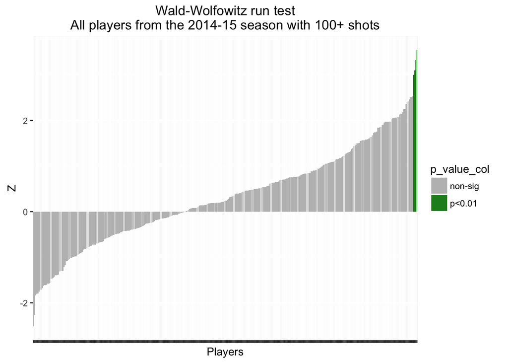

```r
run_test_df_plot <- run_test_df %>%
  mutate(PLAYER_NAME = as.factor(PLAYER_NAME),
         p_value_col = ifelse(RUNS_PVALUE < 0.01, "p<0.01", "non-sig")) %>%
  arrange(-RUNS_STAT)

x_breaks <- levels(run_test_df_plot$PLAYER_NAME)[rep(c(TRUE,FALSE), length(run_test_df_plot$PLAYER_NAME)/2)]
ggplot(run_test_df_plot, aes(x=reorder(PLAYER_NAME, RUNS_STAT), y=RUNS_STAT, fill=p_value_col)) +
  geom_bar(stat="identity", position="identity") +
  scale_fill_manual(values=c("grey", "forest green")) +
  xlab("Players") +
  ylab("Z") +
  theme(axis.text.x = element_blank()) +
  ggtitle(paste0("Wald-Wolfowitz run test", "\n",
          "All players from the 2014-15 season with 100+ shots"))
```

```r
run_test_df_plot %>%
  filter(RUNS_PVALUE < 0.01) %>%
  select(PLAYER_NAME, RUNS_STAT, RUNS_PVALUE) %>%
  knitr::kable(., digits=4)
```

| PLAYER_NAME | RUNS_STAT | RUNS_PVALUE |
| --- | --- | --- |
| Marc Gasol | 3.5491 | 0.0004 |
| Al Jefferson | 3.3238 | 0.0009 |
| Evan Fournier | 3.1034 | 0.0019 |
| Tyler Ennis | 3.0022 | 0.0027 |

## Question 3: Does prev shot predict shot distance?

M&S claim that ing-game is inappropriate for analysis because of confounds such as shot difficulty. We examine one aspect - does streak shooting (or missing) predict `SHOT_DISTANCE`?

### Data prep

```r
shot_dist_plot <- d_prev %>%
  gather(streak_type, streak_value, c(curr_hit_streak, curr_miss_streak)) %>%
  mutate(streak_type = ifelse(streak_type == "curr_hit_streak", streak_type, "_curr_miss_streak"))
```

### Plot

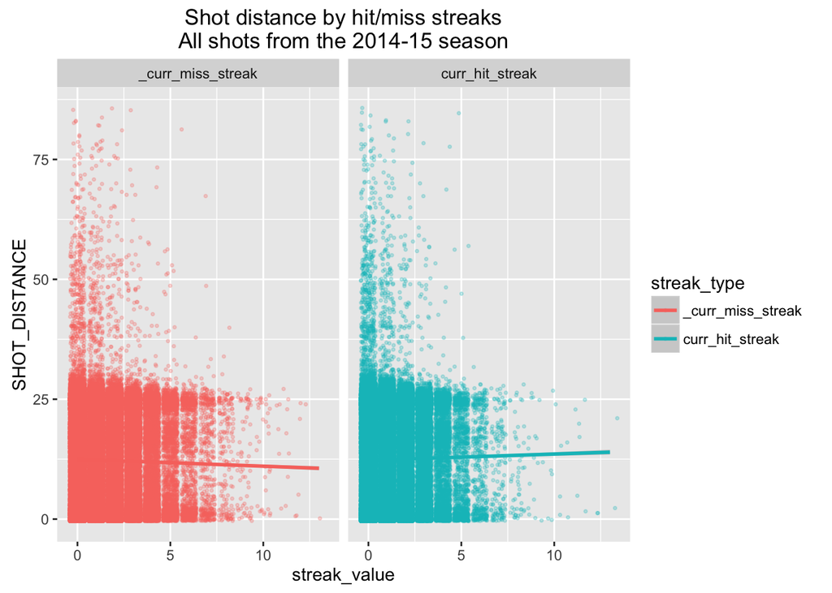

```r
ggplot(shot_dist_plot, aes(x=streak_value, y=SHOT_DISTANCE, col=streak_type)) +
  # geom_point() +
  geom_jitter(alpha=0.25, size=0.6, width=1) +
  facet_wrap(~streak_type) +
  geom_smooth(method="lm") +
  ggtitle(paste0("Shot distance by hit/miss streaks", "\n",
          "All shots from the 2014-15 season"))
```

### Test

Fitting a mixed effects model regressing `SHOT_DISTANCE` on `curr_hit_streak`, `curr_miss_streak` and `player` and `team` level random effects.

```r
# names(d_prev)
sum <- summary(lmer(SHOT_DISTANCE ~
               curr_hit_streak + curr_miss_streak + (1 | PLAYER_ID) + (1 | TEAM_NAME), data=d_prev))
knitr::kable(sum$coefficients, digits=3)
```

|  | Estimate | Std. Error | df | t value | Pr(>\|t\|) |
| --- | --- | --- | --- | --- | --- |
| (Intercept) | 12.246 | 0.298 | 133.14 | 41.108 | 0 |
| curr_hit_streak | 0.272 | 0.022 | 196889.32 | 12.403 | 0 |
| curr_miss_streak | -0.315 | 0.018 | 196898.81 | -17.200 | 0 |

Looks like hot and cold streaks do predict `SHOT_DISTANCE`. This is the first evidence that there might be Hot Hand like effects. Of course this is only indirect. We will certainly want to control of `SHOT_DISTANCE` in our final analysis.

## Question 4: Controlling in-game vars.

```r
predictors <- data.frame("SHOT" = c("curr_streak",
                                    "shot type",
                                    "shot distance",
                                    "shot value"),
                         "PLAYER" = c("height",
                                      "weight",
                                      "age",
                                      "years in league"),
                         "GAME" = c("total time remaining",
                                    "period",
                                    rep(NA, 2)))
knitr::kable(predictors)
```

| SHOT | PLAYER | GAME |
| --- | --- | --- |
| curr_streak | height | total time remaining |
| shot type | weight | period |
| shot distance | age | NA |
| shot value | years in league | NA |

```r
# names(d_prev)
sum <- summary(glm(SHOT_MADE_FLAG ~
                     curr_hit_streak + curr_miss_streak + SHOT_VALUE +
                     TOTAL_TIME_REMAINING + SHOT_DISTANCE + AGE + HEIGHT +
                     WEIGHT + ACTION_TYPE, family="binomial", data=d_prev))
knitr::kable(sum$coefficients[2:3, ], digits=3)
```

|  | Estimate | Std. Error | z value | Pr(>\|z\|) |
| --- | --- | --- | --- | --- |
| curr_hit_streak | -0.004 | 0.005 | -0.779 | 0.436 |
| curr_miss_streak | 0.010 | 0.004 | 2.224 | 0.026 |

# Section IV: Other

### Shooting percentage by shot number

```r
d_prev %>%
  group_by(shot_num) %>%
  filter(shot_num < 30) %>%
  summarize(shots_taken = n(),
            avg_shot_distance = mean(SHOT_DISTANCE),
            shots_made = sum(SHOT_MADE_FLAG),
            shooting_percentage = shots_made / shots_taken,
            ci_lower = binom.test(shots_made, shots_taken)$conf.int[1],
            ci_upper = binom.test(shots_made, shots_taken)$conf.int[2]) %>%
  ggplot(aes(x = shot_num, y = shooting_percentage, fill = avg_shot_distance)) +
    geom_bar(stat = "identity") +
    geom_errorbar(aes(ymin = ci_lower, ymax = ci_upper))
```

```r
d_prev %>%
  ggplot(aes(x=shot_num, y=SHOT_DISTANCE, col=as.factor(SHOT_MADE_FLAG))) +
    geom_point(alpha=0.4) +
    geom_jitter(width=0.5) +
    geom_smooth(method="lm")
```

## League-wide previous shots effects

### Data

```r
calc_prev_shot_effects <- function(df) {
  d_current <- df %>%
    summarize(shots_taken = n(),
              shots_made = sum(SHOT_MADE_FLAG),
              shooting_percentage = shots_made / shots_taken,
              ci_lower = binom.test(shots_made, shots_taken)$conf.int[1],
              ci_upper = binom.test(shots_made, shots_taken)$conf.int[2])
  d_made_last_1 <- df %>%
      filter(made_last_1 == TRUE) %>%
      summarize(shots_taken = n(),
                shots_made = sum(SHOT_MADE_FLAG),
                shooting_percentage = shots_made / shots_taken,
                ci_lower = binom.test(shots_made, shots_taken)$conf.int[1],
                ci_upper = binom.test(shots_made, shots_taken)$conf.int[2])
  d_made_last_2 <- df %>%
      filter(made_last_2 == TRUE) %>%
      summarize(shots_taken = n(),
                shots_made = sum(SHOT_MADE_FLAG),
                shooting_percentage = shots_made / shots_taken,
                ci_lower = binom.test(shots_made, shots_taken)$conf.int[1],
                ci_upper = binom.test(shots_made, shots_taken)$conf.int[2])
  d_made_last_3 <- df %>%
      filter(made_last_3 == TRUE) %>%
      summarize(shots_taken = n(),
                shots_made = sum(SHOT_MADE_FLAG),
                shooting_percentage = shots_made / shots_taken,
                ci_lower = binom.test(shots_made, shots_taken)$conf.int[1],
                ci_upper = binom.test(shots_made, shots_taken)$conf.int[2])
  d_made_last_4 <- df %>%
      filter(made_last_4 == TRUE) %>%
      summarize(shots_taken = n(),
                shots_made = sum(SHOT_MADE_FLAG),
                shooting_percentage = shots_made / shots_taken,
                ci_lower = binom.test(shots_made, shots_taken)$conf.int[1],
                ci_upper = binom.test(shots_made, shots_taken)$conf.int[2])
  d_missed_last_1 <- df %>%
      filter(missed_last_1 == TRUE) %>%
      summarize(shots_taken = n(),
                shots_made = sum(SHOT_MADE_FLAG),
                shooting_percentage = shots_made / shots_taken,
                ci_lower = binom.test(shots_made, shots_taken)$conf.int[1],
                ci_upper = binom.test(shots_made, shots_taken)$conf.int[2])
  d_missed_last_2 <- df %>%
      filter(missed_last_2 == TRUE) %>%
      summarize(shots_taken = n(),
                shots_made = sum(SHOT_MADE_FLAG),
                shooting_percentage = shots_made / shots_taken,
                ci_lower = binom.test(shots_made, shots_taken)$conf.int[1],
                ci_upper = binom.test(shots_made, shots_taken)$conf.int[2])
  d_missed_last_3 <- df %>%
      filter(missed_last_3 == TRUE) %>%
      summarize(shots_taken = n(),
                shots_made = sum(SHOT_MADE_FLAG),
                shooting_percentage = shots_made / shots_taken,
                ci_lower = binom.test(shots_made, shots_taken)$conf.int[1],
                ci_upper = binom.test(shots_made, shots_taken)$conf.int[2])
  d_missed_last_4 <- df %>%
      filter(missed_last_4 == TRUE) %>%
      summarize(shots_taken = n(),
                shots_made = sum(SHOT_MADE_FLAG),
                shooting_percentage = shots_made / shots_taken,
                ci_lower = binom.test(shots_made, shots_taken)$conf.int[1],
                ci_upper = binom.test(shots_made, shots_taken)$conf.int[2])

  d_prev_shot_effects <- rbind(d_made_last_1,
                               d_made_last_2,
                               d_made_last_3,
                               d_made_last_4,
                               d_current,
                               d_missed_last_1,
                               d_missed_last_2,
                               d_missed_last_3,
                               d_missed_last_4) %>%
    mutate(context = c('made_1',
                       'made_2',
                       'made_3',
                       'made_4',
                       'overall',
                       'missed_1',
                       'missed_2',
                       'missed_3',
                       'missed_4'))

  d_prev_shot_effects$context <- factor(d_prev_shot_effects$context, levels = c('made_4',
                                                                                'made_3',
                                                                                'made_2',
                                                                                'made_1',
                                                                                'overall',
                                                                                'missed_1',
                                                                                'missed_2',
                                                                                'missed_3',
                                                                                'missed_4'))
  d_prev_shot_effects
}
```

```r
unique(d_prev$PLAYER_ID)

d_prev %>%
  group_by(PLAYER_ID) %>%
  summarize(shots = n())

d_prev %>% filter(PLAYER_ID == 203994) %>% calc_prev_shot_effects()


d_prev_shots_by_team <- plyr::ddply(d_prev, .variables = c("PLAYER_ID"), calc_prev_shot_effects)

ggplot(d_prev_shots_by_team, aes(x = context, y = shooting_percentage, fill = TEAM_ID)) +
  geom_bar(stat = "identity") +
  geom_errorbar(aes(ymin = ci_lower, ymax = ci_upper)) +
  facet_wrap(~TEAM_ID)
  ggtitle("Impact of previous shot on current shooting percentage\n
          All shots from NBA 2014-2015 season\n
          By team")
```

### Plot

```r
d_prev_shot_effects <- calc_prev_shot_effects(d_prev)
ggplot(d_prev_shot_effects, aes(x = context, y = shooting_percentage)) +
  geom_bar(stat = "identity") +
  geom_errorbar(aes(ymin = ci_lower, ymax = ci_upper)) +
  ggtitle("Impact of previous shot on current shooting percentage\n
          All shots from NBA 2014-2015 season")
```

# Exploring previous shots

```r
d_prev_small <- d_prev[1:10000,]
names(d_prev_small)


d_prev_small %>%
  mutate(hit_last_3_or_more = curr_hit_streak >= 3,
         missed_last_3_or_more = curr_miss_streak >= 3)
summary(lmer(SHOT_MADE_FLAG ~ curr_hit_streak + SHOT_DISTANCE * SHOT_TYPE, family="binomial", data=d_prev_small))

summary(glm(SHOT_MADE_FLAG ~ curr_hit_streak + SHOT_DISTANCE + ACTION_TYPE, family="binomial", data=d_prev_small))
```

## Modeling

```r
summary(glm(SHOT_MADE_FLAG ~ SHOT_TYPE +
              MINUTES_REMAINING +
              SHOT_DISTANCE +
              made_last_1 +
              made_last_2 +
              made_last_3 +
              made_last_4,
            family = "binomial", na.action = "na.omit", data = d_prev))
```

## How many have taken over 500 shots?

```r
player_shots_summary %>%
  filter(total_shots_taken > 500) %>%
  nrow
```

Who made the most shots?

```r
ggplot(player_shots_summary, aes(x = reorder(PLAYER_NAME, total_shots_made), y = total_shots_made, fill = TEAM_NAME)) +
  geom_bar(stat = "identity") +
  guides(col = FALSE) +
  theme(axis.text.x = element_text(angle = 90, hjust = 1)) +
  ggtitle("Shots made by player")
```

OK, who were the top 50 players with the best shooting percentage of players who took more than 50 shots in the season?

```r
top_50_shooting_percentage <- d %>%
  group_by(PLAYER_NAME) %>%
  summarize(total_shots_taken = n(),
            total_shots_made = sum(SHOT_MADE_FLAG),
            shooting_percentage = total_shots_made / total_shots_taken,
            avg_shot_distance = mean(SHOT_DISTANCE)) %>%
  filter(total_shots_taken >= 50) %>%
  arrange(-shooting_percentage) %>%
  head(n = 50)

ggplot(top_50_shooting_percentage, aes(x = reorder(PLAYER_NAME, shooting_percentage), y = shooting_percentage)) +
    geom_bar(stat = "identity") +
    guides(col = FALSE) +
    theme(axis.text.x = element_text(angle = 90, hjust = 1)) +
    ggtitle("Shots made by player")
```

```r
top50_names <- unique(top_50_shooting_percentage$PLAYER_NAME)

d %>%
  mutate(top_50 = ifelse(PLAYER_NAME %in% top50_names, TRUE, FALSE)) %>%
  group_by(PLAYER_NAME) %>%
  summarize(total_shots_taken = n(),
            total_shots_made = sum(SHOT_MADE_FLAG),
            shooting_percentage = total_shots_made / total_shots_taken,
            avg_shot_distance = mean(SHOT_DISTANCE)) %>%
  filter(total_shots_taken >= 50) %>%
  ggplot(aes(x = reorder(PLAYER_NAME, shooting_percentage), y = shooting_percentage, fill = avg_shot_distance)) +
    geom_bar(stat = "identity") +
    theme(axis.text.x = element_text(angle = 90, hjust = 1)) +
    ggtitle("Shots made by player")
```